# R Notebook

```r
library(tidyverse)
```

# Problem 1

## (a)

We know from Bayes’ theorm that $P(y=1|x=c(1,2))= \frac{P(x=c(1,2)|y=1)\times P(y=1)}{P(x=c(1,2))}$,

we know the distribution parameters of $P(x|y=1)$, which is “trained” on the training data. We know prior to seeing the new data, the probablity of observing P(y=1) = 0.5, but what is the probablity of P(x)?? We consider P(x) is considered marginalized (intergrated over all possible values of Y) in our case $P(x)= P(X=c(1,2)|y=1)\times P(y=1) + P(x= c(1,2)|y=0) \times P(y=0)$

Therefore, $P(y=1|x=c(1,2))= \frac{P(x=c(1,2)|y=1) }{P(X=c(1,2)|y=1)\times P(y=1) + P(x= c(1,2)|y=0) \times P(y=0)} \times P(y=1)$

Note this fractions are composed of density values, and do we claim this as a likelihood ratio?

Lets get the probablity density values for the fraction terms,

```r
p1 <- mvtnorm::dmvnorm(x=c(1,2) ,mean= c(0,0),sigma = matrix(c(1,0,0,1),nrow = 2,byrow = T) )
p0 <- mvtnorm::dmvnorm(x=c(1,2), mean= c(0,0),sigma = matrix(c(16,0,0,16),nrow = 2,byrow = T) )

p1/(p1+p0)*0.5
```

```
[1] 0.3027982
```

so the posterior probablity is p1/(p1+p0)*0.5 = 0.3027982

## (b)

we are going to : 1)design how to generate the grid  
2)then compute the density for all the grid points 3)create a scatter plot based on grid points coordinates 4)using the grid points coordinates and their corresponding density value to add the contour plot onto the scatter plot

How to generate the grid ? we want the contour plot to be in the ceter of grid point area. In other word we are trying to find x1,x2 that maximize $(P(Y= +1|X) )$, according to the description we know it is (0,0).

We also want to decide the range of grid points that it covers more than 99%(lets say 99.7%, 3) interval for x1,x2 so the range should no smaller than (-12,12) for both x1 and x2.

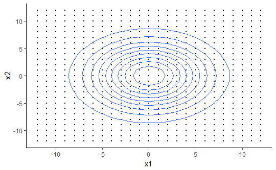

```r
cov_mat <- matrix(c(16, 0,0,16  ),nrow = 2,byrow = T)
grid_mat <- expand.grid((-12:12),(-12:12)) # get input gird coordinates
den_vec = mvtnorm::dmvnorm(x = grid_mat,mean = c(0,0), sigma =  cov_mat ) #get the density

df <- cbind(grid_mat,den_vec)
colnames(df) <- c("x1","x2","p")

df %>%
  ggplot() +
  geom_point(aes(x=x1,y=x2),size = 0.1)+
  geom_contour(aes(x=x1,y=x2,z=p))+
  theme_classic()
```

## (c)

since naive bayes classifier above is a special case of LDA, with off-diagnol terms all equal to zero. and that LDA are specical cases of QDA where *{-} =* {+}. Therefore naive bayes classfier (described above) is a special case of QDA.

## (d)

For Gaussian) naive Bayes classifier (let us assume m classes classfication), we assume a equal variance for pos and neg distributions and zero covariances for both distributions. which means (p (No. of mean) + p (No. of variance)) *m (No. distribution) which is 2mp

in QDA it is (p + p(p + 1)/2)*m =1.5 mp + 0.5mp^2

since p >1 and m >1 it is clear that QDA is more complex. This means QDA is more likely to be overfitting and the number of training data points required to achieve the asymptotic error is higher in QDA

# Problem 2

## a

lets first generate a training sample (n=100) first generate y from the distribution, then generate x1 and x2 values based on the y value randomly (by following the distribution)

```r
set.seed(1234)
y <- sample (0:2, size =100, replace =T, prob = c(0.4,0.3,0.3))


prob0 <- c(0.6,0.1,0.1,0.1,0.1,0.0)
prob1 <- c(2,1,4,2,0,1) /10
prob2 <- c(1,4,3,0,2,0) /10
prob_list <- list(prob0,prob1,prob2)
X= matrix(-200:-1,nrow = 100, byrow = T )
colnames(X) <- c("x1","x2")
# lets try use a list column and map function in purrr. when there are time


for (i in 1:100){
  prob <- prob_list[[(y[i]+1)]]
  X[i,] <- unlist(expand.grid(x1=0:1,x2=0:2)[sample(1:6, 1, replace=TRUE, prob=prob),])
}

table(y)
```

```
y
 0  1  2
51 22 27
```

```r
table( apply(X = X, MARGIN = 1, FUN = sum))
```

```
 0  1  2  3
39 41 19  1
```

## (b)

compute the class conditional probablity distribution( The probablity of observing an given independent variable being a certain value under the condition of y equals to a certain value, marginalized over all the value of other independent variables) (several different smoothing method will be used)

$P(X_{i}= x|Y = c)= \frac{n_{y,j,x}+m}{n_{y}+ m_1}$

where m and m1 changes according to different smoothing method

all the count values for the fomula given above come from training data which is a random sample from a known distribution.

```r
train <-
    cbind(X, y) %>%
    tbl_df() %>%
    group_by_all %>%
    mutate(count=1) %>%
    summarise(count_cat= sum(count) ) %>%
    ungroup()


#tranlate the above formula that can calculate conditional probablity into a function with four parameters,  name of the x variable,  its corresponding value, value of response variable and pseudocounts.



con_p_fun <- function(x_var, x_var_value, y_value,m, alpha_based= F ){
  x_var1 <- x_var
  ensym(x_var)
  #get the count from the training data
  n_y= train  %>%
    filter(y== y_value) %>%
    #summarise(count= sum(count_cat)) %>%
    pull(count_cat) %>%
    sum


  n_yjh =
    train %>%
    filter(get(!!x_var) == x_var_value ) %>%
    filter(y == y_value) %>%
    pull(count_cat) %>%
    sum

    if (x_var1 == "x1" & alpha_based == F ){
    m1= 2* m
  } else {
    m1=3*m
  }
  p = (n_yjh + m) / (n_y + m1)
  return(p)
}
```

Now what is the expected marginal probablity to observe x1=1 and y=1

```r
#con_p_fun(x_var = "x1",x_var_value = 1)
con_p_fun(x_var = "x1",x_var_value = 1,m = 1,alpha_based = F,y_value = 1)
```

```
[1] 0.375
```

since both input and output are discreate, Lets’ list all the possible conditions and calulate the corresponding conditional probablities

generate a table that list all the conditions

```r
cond1 <- train %>% select(1,3) %>% distinct() %>% mutate(x_var = "x1") %>% rename(x_value=x1)
cond2 <- train %>% select(2,3) %>% distinct() %>% mutate(x_var = "x2") %>% rename(x_value=x2)
cond_df <- rbind(cond1,cond2)%>% select(x_var,x_value,y)
```

Now using each row from the condition table as input for the function defined above to compute probabliteies as a new column for the table (okay here I got stuck when tring to use the fancy pmap function, lets first try to use a dummier for loop to finish the work)

```r
p1 <- p2 <- p3  <- p4 <- p5 <- p6 <- 1:nrow(cond_df)
for (i in 1:nrow(cond_df)){
  a= cond_df$x_var[i]
  b= cond_df$x_value[i]
  c= cond_df$y[i]
  p1[i] <- con_p_fun(x_var = a,x_var_value =b ,y_value =c ,m =0,alpha_based = F)
  p2[i] <- con_p_fun(x_var = a,x_var_value =b ,y_value =c ,m =1,alpha_based = F)
  p3[i] <- con_p_fun(x_var = a,x_var_value =b ,y_value =c ,m =0.5,alpha_based = F)
  p4[i] <- con_p_fun(x_var = a,x_var_value =b ,y_value =c ,m =0, alpha_based = T)
  p5[i] <- con_p_fun(x_var = a,x_var_value =b ,y_value =c ,m =1, alpha_based = T)
  p6[i] <- con_p_fun(x_var = a,x_var_value =b ,y_value =c ,m =0.5, alpha_based = T)
}


cond_df <- cond_df %>%
  mutate(p1 = p1) %>%
  mutate(p2 = p2) %>%
  mutate(p3 = p3) %>%
  mutate(p4 = p4) %>%
  mutate(p5 = p5) %>%
  mutate(p6 = p6)
```

## (c)

so I should construct a table to represent my estimated model, where there are three columns, x1,x2, expected y, so that if there comes in new data point with x1 and x2 values but no y values, I can quickly predict the y by checking the table.

Now let transform the condition probility table we had for question (b) into the desired form for (c)

we have P(x1|Y) and P(x2|Y) from the table, lets then compute P(Y), P(x1) and P(x2) from this table,

the problem is I need to calculate P(y), P(X1), P(X2) from the training data but actually this is qute easy, they are uniform across different forms of models, lets just derive those from the training data table

```r
#get probalities vectors
py <- table(y)/100
px1 <- table(X[,1])/100
px2 <- table(X[,2])/100

# intialize model table
model_table <- data.frame(expand.grid(x1=0:1,x2=0:2))
Pred= matrix(data = -36:-1,nrow = 6)
check= matrix(data = -9:-1,nrow = 1)

#(number of models)
for (i in 1:6){
  column_name= (colnames(cond_df)[4:9])[i]
  sym(column_name)
  #(number of combinations for x1 and x2)
  for (a in 1: 6) {
    x1= model_table$x1[a]
    x2= model_table$x2[a]
    quo(x1)
    quo(x2)
    #(number of possible y)
    p= -3:-1
    for (b in 1:3) {
      y_value = c(0,1,2)[b]
      quo(y_value)
      p1 <- cond_df %>% filter(x_var== "x1") %>% filter(x_value== !!x1)%>% filter(y== !!y_value) %>% pull(!!column_name)
      p2 <- cond_df %>% filter(x_var== "x2") %>% filter(x_value== !!x2)%>% filter(y== !!y_value) %>% pull(!!column_name)
      p3 <- py[b]
      p4 <- px1[x1+1]
      p5 <- px2[x2+1]
      p[b] <- p1*p2*p3/(p4*p5)
     # w<- c(x1,x2,y_value,p1,p2,p3,p4,p5,p[b])
      # check <- rbind(check,w)
     # print(w)
    }
    y_pred <- c(0,1,2)[which.max(p)]

    Pred[a,i] <- y_pred
  }


}

check <- cbind(model_table, Pred)
```

lets now generate the test sample

```r
#set.seed(1234)
y_test <- sample (0:2, size =10000, replace =T, prob = c(0.4,0.3,0.3))


prob0 <- c(0.6,0.1,0.1,0.1,0.1,0.0)
prob1 <- c(2,1,4,2,0,1) /10
prob2 <- c(1,4,3,0,2,0) /10
prob_list <- list(prob0,prob1,prob2)
X_test= matrix(-20000:-1,nrow = 10000, byrow = T )
colnames(X_test) <- c("x1","x2")


for (i in 1:10000){
  prob <- prob_list[[(y_test[i]+1)]]
  X_test[i,] <- unlist(expand.grid(0:1,0:2)[sample(1:6, 1, replace=TRUE, prob=prob),])
}

# table(y)
# table( apply(X = X, MARGIN = 1, FUN = sum))

test <-
    cbind(X_test, y_test) %>%
    tbl_df()
```

#what is the performance? Lets organize the loss as sum of number of misclassfication cases

```r
caret::confusionMatrix(data= test1$p1, reference= test1$y_test)[["overall"]][1]
```

```
Accuracy
  0.4117
```

```r
caret::confusionMatrix(data= test1$p2, reference= test1$y_test)[["overall"]][1]
```

```
longer object length is not a multiple of shorter object lengthLevels are not in the same order for reference and data. Refactoring data to match.
```

```
Accuracy
  0.3493
```

```r
caret::confusionMatrix(data= test1$p3, reference= test1$y_test)[["overall"]][1]
```

```
longer object length is not a multiple of shorter object lengthLevels are not in the same order for reference and data. Refactoring data to match.
```

```
Accuracy
  0.3493
```

## d

lets store a cond_df1 first to make life easier

```r
  cond1 <- train %>% select(1,3) %>% distinct() %>% mutate(x_var = "x1") %>% rename(x_value=x1)
  cond2 <- train %>% select(2,3) %>% distinct() %>% mutate(x_var = "x2") %>% rename(x_value=x2)
  #note you can't use this to genrate a full condition since the sample drawn randomly from the distribution may not contain some specifc value.
  cond_df1 <- rbind(cond1,cond2)%>% select(x_var,x_value,y)
```

```r
sim
```

```
[1] 12
```

wait, it may be that by chance the test dataset are not a good representative of the underlying distribution for the population.